# Introduction

Statisticians use graphs in almost every stage of their work: we create charts when we get new data, to explore what we have and identify potential problems and opportunities. We fit models based on relationships between variables which are often identified visually. We identify problems with those models based on residual plots and other visual diagnostics. When our modeling work has been completed, we present our results to interested parties using visual displays, because non-statisticians often find it easier to understand data and models through an intuitive visual medium rather than through the mathematical formulae which underlie the statistical work.

Given the wide range of uses for graphs and visual data displays in statistical modeling, it is unsurprising that some graphs are more useful for specific applications such as exploratory analysis, and are unsuitable for other applications, such as presentation to an outside group. In addition, we know that not all visual displays have equal perceptual value [@aspillaga1996]. The best graphics are designed to account for both the features of the dataset and the features of the intended audience. Some design constraints stem from limitations of the human perceptual system and are common to most potential consumers of the visualization: the sine illusion [@vanderplas2015] affects anyone with binocular depth perception, and color recommendations are built around the specific characteristics of the human retina. Other design constraints are due to the audience’s experience level: are they used to working with data? Do they understand specialized techniques such as principal component analysis to the point where a plot of factor loadings might be useful ? When we create visualizations for public consumption we have to consider both perceptual factors and the target audience’s domain knowledge. In this introduction, we explore previous research related to the construction of interactive and static visual displays for different audiences and consider the implications of this research when designing interactive data displays such as dashboards.

For example, in sports, many coaches desire printable diagrams containing all necessary and valuable information on a single page. As data in sports becomes more prominent, extensive, and collected, this information must be refined.

## Audience Considerations

Several factors, including perception, attention, and expertise, can influence our desire and ability to read and engage with data visualization.

### Perception

Gestalt principles include:

- Proximity: Objects close to each other are perceived as related or grouped.
- Similarity: Objects that are similar in some way (e.g., shape, color, size) are perceived as related or grouped.
- Continuation: The human eye follows lines and patterns, so designers can use this principle to guide the viewer’s gaze through a display.
- Closure: The human brain tends to complete incomplete figures or patterns, so designers can use this principle to create the illusion of missing information.
- Figure-Ground: The human brain separates the foreground (figure) from the background (ground), so designers can use this principle to create visual hierarchy and emphasis.
- Contrast: The human eye is drawn to high-contrast areas, so designers can use this principle to create emphasis and hierarchy.
- Symmetry and Balance: The human eye finds symmetry and balance visually pleasing, so designers can use this principle to create a sense of harmony and order.

[figure not shown]

Gestalt Principles with Examples

### Attention and Memory

Short-term memory (STM), also known as working memory, is the stage of temporary storage and processing where the majority of memory retention effort is expended. According to @baddeley2012, STM is a limited-capacity system prone to interference and decay. Selective attention is essential for the maintenance of STM because it allows us to filter out irrelevant information and concentrate on what is essential @cowan2001.

Visual aids such as charts and diagrams can improve short-term memory by allowing us to encode and retain information more effectively, according to research @alvarez2004.

Consequently, utilizing visual aids such as charts can be advantageous for enhancing our short-term memory.

Furthermore, annotations can also be useful in aiding short-term memory. By adding annotations, such as notes or highlights, to information we are trying to remember, we can improve our recall of the information later on @alvarez.

According to the Feature Integration Theory (FIT), STM is composed of two stages: pre-attentive processing and focused attention @treisman1998. Parallel and independently, the brain processes the physical characteristics of an object, such as its color, shape, and orientation, during pre-attentive processing. However, focused attention is required to bind these features into a coherent object representation in STM. STM can be improved through various strategies, such as rehearsal, chunking, and elaboration @oberauer2009. For example, by repeating a phone number several times or breaking it down into chunks of two or three digits, we can increase the likelihood of it being stored in STM. Similarly, by elaborating on the information we want to remember, such as creating mental associations or visual images, we can enhance its retention in STM @bui2015.

STM is a dynamic and malleable cognitive system that is crucial to our daily lives. Understanding the mechanisms underlying STM and how to improve it can have significant implications for learning, memory, and the treatment of memory disorders.

### Constructing Meaning

Gestalt psychology suggests that humans actively construct meaning by organizing information into patterns and wholes @wertheimer1923. Both top-down and bottom-up processing are involved in the process of meaning construction. Bottom-up processing entails analyzing sensory data from the environment and constructing perceptions based on this data. Top-down processing is the influence of prior knowledge, expectations, and context on the perception and interpretation of incoming sensory data.

Together, top-down and bottom-up processing facilitate the encoding and retrieval of information in the context of short-term memory. Selective attention, the ability to focus on relevant information while ignoring irrelevant information, is an example of top-down processing that aids in the encoding and retrieval of information in short-term memory @cowan2010.  
According to the feature integration theory, the perception of objects involves both the bottom-up analysis of individual features and the top-down processing of higher-level features in order to form a complete perception @treisman1980.

The Gestalt principles of perception emphasize the significance of bottom-up and top-down processing in constructing meaning from sensory data. Both types of processing are involved in encoding and retrieving information, which has significant implications for understanding how short-term memory works.

### Expertise

The development of expertise is a gradual and iterative process that is influenced by numerous psychological factors, such as cognitive processes, automaticity, readily accessible information, and practice effects.

Cognitive Processes - the way we think about and approach a task.

As we become more proficient in a particular skill, we develop more complex and efficient mental models or schemata. These mental models help us to organize information in a meaningful way, and to quickly identify and solve problems related to the task. This process is known as cognitive restructuring and is facilitated by developing domain-specific knowledge @ericsson1996. For example, a chess master is able to quickly recognize patterns and positions on the board that are common in chess, which allows them to make decisions more quickly and accurately than a novice player.

Automaticity - the ability to perform a task without conscious effort or attention

As our proficiency in a task increases, our performance becomes more automatic, thereby freeing up cognitive resources for other tasks. The development of procedural knowledge, which is the ability to perform a series of steps or actions in a particular order, facilitates this process @Fitts1967. For instance, a skilled typist can type without looking at the keyboard because their finger movements have become automatic.

Information Readily Available - the way we process information related to a task

As our proficiency increases, we can recognize and retrieve pertinent information more rapidly and precisely than a novice. This is made possible by the creation of domain-specific knowledge structures that allow us to retrieve pertinent information from memory quickly @Chase1973. For instance, a medical expert can quickly identify signs and diagnose a patient using their knowledge of disease symptoms and risk factors.

Practice Effects - extensive practice and experience

Practice effects are the performance enhancements that result from repeated practice. These gains are frequently most significant at the outset of practice, but gradually diminish as the individual approaches their performance ceiling @Anderson1982. The development of procedural knowledge and automaticity, which allow for more efficient and accurate task performance, facilitates the effects of the practice.

### Engagement with the data

William Cleveland’s subcycle plots:

- glyph maps and binned graphics emerging from big data visualization efforts.
- glyphs and other plots have been embedded in maps

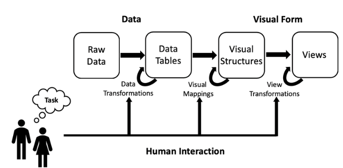

Visual Reference model by Card

Colin Ware “Information Visualization: Perception for Design” [@Ware2004] there are four stages of visualization

- The collection and storage of data itself
- The preprocessing design to transform the data into something we can understand
- The display hardware and the graphics algorithms produce the image on the screen.
- The human perceptual and cognitive system
- Identified the highly relevant from a dashboard design perspective [@odonnell2000]
1. Information systems give interaction and feedback
2. Type of presentation format to be used
3. Differences in the amount of information load.

Information load is essential, as dashboards must provide the right decision cues without overwhelming the user with excess information.

- Graphs are more suitable for spatial tasks (ex., for comparing a set of values) [@vessey1991];[@umanath1994];[@vessey1994]
- Graphs reduced the negative influence of information overload
- Graphs produced better correlation estimates and decreased time on a task [@schulzand];[@booth2006]
- Self-organizing maps and multidimensional scaling did not significantly outperform tabular representations [@huang2006]

The purposes of a dashboard:

1. Consistency
2. Monitoring
3. Planning
4. Communication

Visual Data Mining

The visual data exploration process can be seen as a hypothesis generation process:

- The visualizations of the data allow the user to gain insight into the data and come up with new hypotheses
- Along with verification of the hypotheses

The main advantages of visual data exploration over automatic data mining techniques from statistics or machine learning are:

- visual data exploration can efficiently deal with highly inhomogeneous and noisy data.
- visual data exploration is intuitive and requires no understanding of complex mathematical or statistical algorithms or parameters.
- overview first
- zoom and filter
- details-on-demand

Visualization Technique Classification:

- Standard 2D/3D displays such as bar charts and x-y plots
- Geometrically transformed displays, such as landscapes and parallel coordinates, as used in a scalable framework
- Icon-based displays such as needle icons and star icons as used in MGV
- Dense pixel displays such as the recursive pattern and circle segments techniques and the graph sketches as used in MGV
- Stacked displays, such as treemaps or dimensional stacking

Interaction and distortion techniques allow users to interact directly with the visualizations.

- Projection as used in the Grand Tour System
- Filtering as used in Polaris
- Zooming as used in MGV and scalable framework
- Linking and Brushing as used in Polaris and the scalable framework

Design Theory in Information System

The knowledge is distinguished as the fifth of five types of theory:

1. Analyzing & describing
2. Understanding
3. Predicting
4. Explaining and predicting
5. Design and action

The two paradigms characterize much of the research in the Information systems discipline:

- *Behavioral Science Paradigm* - seeks to develop and verify theories that explain or predict human or organizational behavior (roots in natural science research methods).
- *Data Science Paradigm* - seeks to extend the boundaries of human and organizational capabilities by creating new and innovative artifacts (roots in engineering and the sciences of the artificial) [@simon1996].
- constructs (vocabulary & symbols)
- models (abstractions & representations)
- methods (algorithms & practices)
- instantiations (implemented & prototype systems)

## Data Considerations

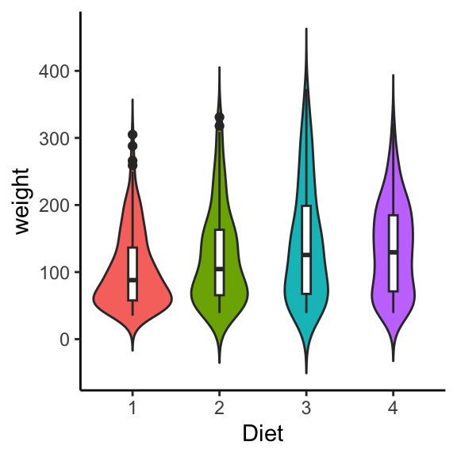

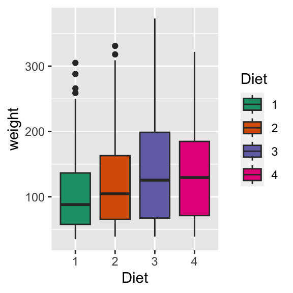

1. Graphical exploration looking for patterns or displaying fit.
- The method demonstrates things about data that are not understood by a single numeric metric. This has been useful in graphing the data before you develop summary statistics.
2. Describing the general patterns of the data.
- This step should be insensitive to outliers. In general, think about the types of resistant measures (i.e., median or mean). This step is making sure to determine data patterns.
3. The natural scale/state that the data are at their best. This will be the step at which the scale of data can be helpful for analysis. The reexpressing data to a new scale by taking the square root or logarithmic scale.
4. The mostly known parts of EDA but is done in the way of accessing fit of the data. This is taught in every statistics 101 class. The growth of machine learning and prediction methods have now used residuals more in the toolbox to assessing the best prediction models.
- The idea generally is to determine the deviations in the data from a general pattern by looking at the data from the fit of the data.}

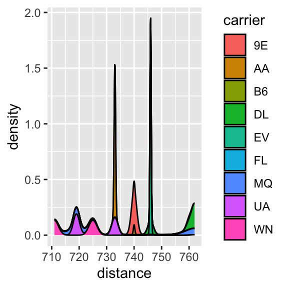

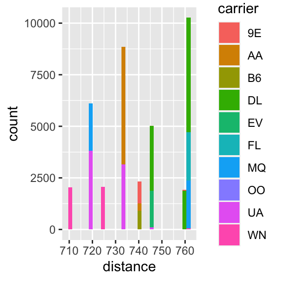

### Variable Types

Not all variables should be used to create all types of charts - variable type informs chart structure

- scatterplots: use dots in coordinate to present data points.
- parallel coordinates: present each dimension as axes, and every data item intersects dimensions as a polygon line at a particular position
- RadViz/ PolyViz
- GridViz

### Grammar of Graphics

It doesn’t help us decide which is better - for that we need user testing.

The components of the grammar of graphics include:

- Data: The raw data being visualized represents a set of observations or values.
- Aesthetic Mappings: The mapping of data variables to visual properties such as position, color, shape, and size.
- Scales: The mapping of data values to visual values, such as mapping a numerical value to a bar height.
- Geometries: The basic shapes representing the data, such as points, lines, bars, and histograms.
- Facets: The plot division into multiple subplots, each representing a different subset of the data.

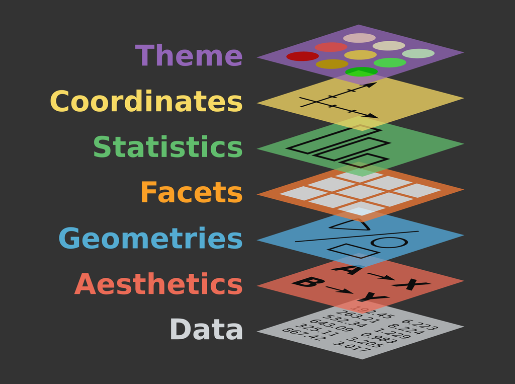

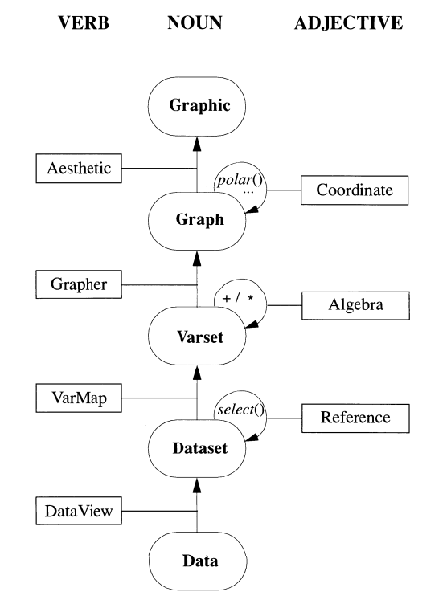

Grammar of Graphics Diagram of Wickham and Wilkinson’s work

#### Interactive Graphics

- graphical comprehension ([@cleveland1984])
- preattentive processing ([@ware2012])
- gestalt theory ([@few2009])
- graphical excellence ([@tufte2001])

Theories behind the manipulation of visualizations include but are not limited to:

- cognitive fit ([@vessey1991])
- visual perceptual approaches ([@baker2009])
- human information processing

### Multivariate Data Displays

- Difficulty of visualizing multivariate data
- Different approaches - briefly mention
  - encoding with shape/color/etc.
  - tours
  - pcps
  - linked graphics (interactivity)

This section doesn’t need to solve the problem - it just introduces it

## Audience-Data Interactions

Several methods can be used to conduct user analysis:

- Interviews: This involves conducting in-depth interviews with users to understand their needs, goals, and workflows.
- Surveys involve sending out surveys to users to gather data on their needs and preferences.
- Observations: This involves observing users as they complete tasks with the interface to understand their behaviors and workflows.
- Personas: This is a method of creating fictional characters that represent the different types of users; it helps to understand the users’ needs and goals.
- Scenarios: This is a method of creating stories that describe how a user might interact with a system; it helps to understand the context and the user’s needs.
- Focus groups: This is a method of gathering a small group of users and facilitating a discussion to understand the users’ needs and goals.
- Contextual inquiry: This is a method of visiting the users in their work environment and observing them while they work; it helps to understand the context and the user’s needs.

### Testing static graphics

Brief overview of user studies that compare different types of graphics, accuracy, etc.

- Usability testing: This involves having users interact with the dashboard and providing feedback on its usability, including how easy it is to navigate, understand, and use.
- Cognitive walkthrough: This involves having experts in human-computer interaction evaluate the dashboard, focusing on the cognitive processes required to use it effectively.
- Eye-tracking: This involves using technology to track the users’ gaze and interactions, to understand the user’s focus and attention on the dashboard elements.
- A/B testing: This involves creating two versions of the dashboard, each with slightly different design elements, and comparing the results to see which design is more effective.
- Surveys: This involves asking users to complete a survey that measures their satisfaction and understanding of the dashboard and to provide feedback on improvements.
- Heat maps: This involves using heat maps to track where users are clicking on the dashboard to identify which elements are being used the most and which are being ignored.
- Card sorting: This is a method to understand the users’ mental models and how they would like to organize and categorize the data; it is helpful to understand how to structure the dashboard navigation.

### Testing interactive graphics

Overview of testing methods for interactive graphics - talk aloud, measuring user engagement, etc.

## Dashboard Design

Given that the audience has limitations, there are design constraints around the data, and the ability of the audience to successfully use the graphical displays of the data, what can we take from this body of research that applies to more complicated sets of graphics?

How do we maintain user attention, desire to explore, and accurately communicate the data through the medium of an interactive data dashboard?

- Achieve specific objectives
- Fits on a single computer screen
- Information can be displayed in multiple mediums (web browser or mobile device)
- Can be used to monitor information at a high level
- PCPs enable the display of multi-dimensional data in two-dimensional space.
- There must be some loss of information, but this can be partly counteracted by varying the order of the axes.
- Interactivity is valuable for reordering the axes flexibly and fast.
- Interaction is valuable for dealing with the dense mass of lines produced by large data sets.
1. The context of the activity being performed by the user
2. The partnership between the researcher and the participant
3. The spoken verification that the investigator’s interpretation of the activity matches the user’s
4. The focus of the study is central to the approach taken by the interviewer
- Hackers: who build processes chaining together multiple programming languages of different types (analytical, scripting, and database languages) and use visualization in various environments.
- Scripters: who perform most of their analysis in an analytical environment (e.g., R or Python) and execute the most complex statistical modeling of the types but who do not performstatements their ETL
- Application Users: who performed most or all of their work in an application such as Excel or SPSS and, like scripters, relied on others (namely, their organizations’ IT departments) for ETL.